# **JAPAN HOUSEHOLD SPENDING 2000-2017 : A STRUCTURAL STORY**

### **Insight 3: The Tax Hike of 2014 Was a Permanent Reset, Not a Temporary Dip**

**Business Importance:** Japan's April 2014 consumption tax increase (5% to 8%) is one of the most studied policy events in Japanese economics. A slope chart comparing 2013 vs 2015 directly quantifies its permanent impact — and reveals which categories absorbed the shock versus which were structurally damaged. This has direct implications for companies considering Japan pricing strategy around any future tax change.

**Design Choices — Course Principles Applied:**

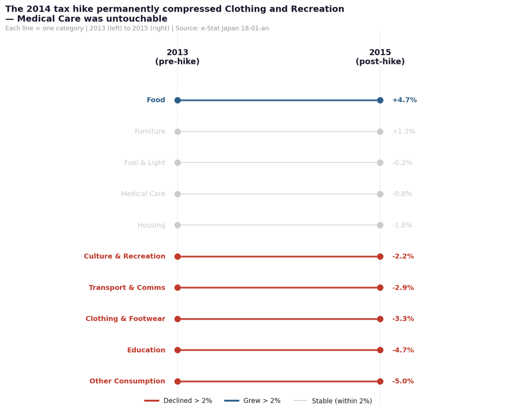

```python
pre  = df_top.loc[2013]
post = df_top.loc[2015]
pct  = ((post - pre) / pre * 100).sort_values()
cats = pct.index.tolist()
n    = len(cats)

fig, ax = plt.subplots(figsize=(10, 8))

for i, cat in enumerate(cats):
    vp = pre[cat]  / 1000
    vq = post[cat] / 1000
    p  = pct[cat]

    c  = ACCENT if p < -2 else (BLUE if p > 2 else '#CCCCCC')
    lw = 2.5 if abs(p) > 2 else 1.0
    fw = 'bold' if abs(p) > 2 else 'normal'

    ax.plot([0, 1], [i, i], color=c, linewidth=lw, alpha=0.9, zorder=3)
    ax.scatter([0, 1], [i, i], color=c, s=60, zorder=4)

    ax.text(-0.06, i, cat,
            ha='right', va='center',
            fontsize=9.5, color=c, fontweight=fw)

    ax.text(1.06, i, "{:+.1f}%".format(p),
            ha='left', va='center',
            fontsize=9.5, color=c, fontweight=fw)

ax.text(0, n + 0.1, "2013\n(pre-hike)",
        ha='center', va='bottom',
        fontsize=11, fontweight='bold', color=DARK)
ax.text(1, n + 0.1, "2015\n(post-hike)",
        ha='center', va='bottom',
        fontsize=11, fontweight='bold', color=DARK)

ax.axvline(0, color='#EEEEEE', linewidth=1, zorder=1)
ax.axvline(1, color='#EEEEEE', linewidth=1, zorder=1)

ax.set_xlim(-0.85, 1.65)
ax.set_ylim(-0.8, n + 1.2)
ax.axis('off')

leg = [
    Line2D([0],[0], color=ACCENT,    lw=2.5, label='Declined > 2%'),
    Line2D([0],[0], color=BLUE,      lw=2.5, label='Grew > 2%'),
    Line2D([0],[0], color='#CCCCCC', lw=1.0, label='Stable (within 2%)'),
]
ax.legend(handles=leg, frameon=False, fontsize=9,
          ncol=3, loc='lower center', bbox_to_anchor=(0.5, -0.01))

ax.set_title("The 2014 tax hike permanently compressed Clothing and Recreation\n— Medical Care was untouchable",
             fontsize=12, fontweight='bold', color=DARK, pad=14, loc='left')
ax.text(0, 1.0,
        "Each line = one category | 2013 (left) to 2015 (right) | Source: e-Stat Japan 18-01-an",
        transform=ax.transAxes, fontsize=8.5, color='#999999', va='bottom')

plt.tight_layout()
plt.savefig('insight3_slope_taxhike.png', dpi=150, bbox_inches='tight')
plt.show()
```